# Taller Individual Analisis Numerico

Realizado por Brayan Jesus Gonzalez Aguilera
**Punto 1**
Resolver el problema de valor inicial, utilizando el método de Runge-Kutta de orden tres y de orden cuatro, obtenga: a.) 20 puntos de la solucion con $h=0.1$ y $h=0.2$, b.) Encuentre los errores locales y el error global, c.) Realice una grafica que compare la solucion aproximada con la exacta, para la ecuacion:
$$X''+6X-X'=0; X(0)=2, X'(0)=-1$$

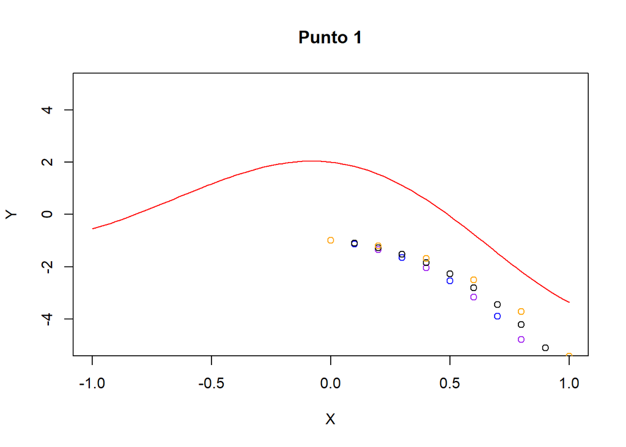

```r
#Realizado por Brayan Jesus Gonzalez Aguilera
#Solucion punto 1
library(deSolve)
fp = function(t,y, parms){
  s = y -6*t
  return(list(s))
}

h <- 0.1
h2<- 0.2
tis= seq(0,20*h,h)
tis2= seq(0,20*h2,h2)
#Soluciones por rk3
sol = ode(c(2,-1), tis, fp, parms=NULL, method = "rk")
sol2 = ode(c(2,-1), tis2, fp, parms=NULL, method = "rk")
#Soluciones por rk4/euler
sol3 = ode(c(2,-1), tis, fp, parms=NULL, method = "euler")
sol4 = ode(c(2,-1), tis2, fp, parms=NULL, method = "euler")
exacta <- function(x){ return(exp(x/2)*(2*cos(sqrt(23)*x/2)-4/sqrt(23)*sin(sqrt(23)*x/2)))}

#Grafica Solucion exacta y Puntos de la solucion
plot(exacta,xlim=c(-1,1),ylim=c(-5,5), col="red", xlab = "X", ylab= "Y",main="Punto 1")
par(new=T)
points(tis,sol[,3],xlim=c(-1,1),ylim=c(-5,5),col="blue")
points(tis2,sol2[,3],xlim=c(-1,1),ylim=c(-5,5),col="purple")
points(tis,sol3[,3],xlim=c(-1,1),ylim=c(-5,5),col="black")
points(tis2,sol4[,3],xlim=c(-1,1),ylim=c(-5,5),col="orange")
```

```r
options( digits = 5)
v <- c()
v2 <- c()
er <- c()

v3 <- c()
v4 <- c()
er2 <- c()

v5 <- c()
v6 <- c()
er3 <- c()

v7 <- c()
v8 <- c()
er4 <- c()

for( i in 1:20 ){
  v <- c(v,sol[i,3])
  v2 <- c(v2,exacta(i*h) )
  er <- c(er, abs( sol[i,3] - exacta(i*h) ) )
}

for( i in 1:20 ){
  v3 <- c(v3,sol2[i,3])
  v4 <- c(v4,exacta(i*h2) )
  er2 <- c(er2, abs( sol2[i,3] - exacta(i*h2) ) )
}

for( i in 1:20 ){
  v5 <- c(v5,sol3[i,3])
  v6 <- c(v6,exacta(i*h) )
  er3 <- c(er3, abs( sol3[i,3] - exacta(i*h) ) )
}

for( i in 1:20 ){
  v7 <- c(v7,sol4[i,3])
  v8 <- c(v8,exacta(i*h2) )
  er4 <- c(er4, abs( sol4[i,3] - exacta(i*h2) ) )
}


tabla = cbind( v[1:20] , cbind( v2[1:20], er[1:20]) )
colnames(tabla) = c("Solucion Numerica rk con h = 0.1", "Solucion Exacta ","Error")
tabla
```

```
##   Solucion Numerica rk con h = 0.1 Solucion Exacta    Error
## 2                          -1.0000         1.834138  2.8341
## 2                          -1.1362         1.535671  2.6719
## 2                          -1.3498         1.109393  2.4592
## 2                          -1.6490         0.568626  2.2176
## 2                          -2.0428        -0.064716  1.9781
## 2                          -2.5410        -0.760605  1.7804
## 2                          -3.1548        -1.481923  1.6729
## 2                          -3.8963        -2.186057  1.7102
## 2                          -4.7788        -2.826988  1.9518
## 2                          -5.8172        -3.357826  2.4594
## 2                          -7.0280        -3.733662  3.2943
## 2                          -8.4291        -3.914598  4.5145
## 2                         -10.0408        -3.868773  6.1720
## 2                         -11.8851        -3.575218  8.3098
## 2                         -13.9864        -3.026310 10.9601
## 2                         -16.3718        -2.229657 14.1421
## 2                         -19.0712        -1.209225 17.8620
## 2                         -22.1176        -0.005548 22.1120
## 2                         -25.5475         1.325069 26.8725
## 2                         -29.4012         2.712430 32.1136
```

```r
tabla2= cbind( v3[1:20] , cbind( v4[1:20], er2[1:20]) )
colnames(tabla2) = c("Solucion Numerica rk con h = 0.2", "Solucion Exacta ","Error")
tabla2
```

```
##   Solucion Numerica rk con h = 0.2 Solucion Exacta      Error
## 2                          -1.0000         1.535671   2.53567
## 2                          -1.3498         0.568626   1.91843
## 2                          -2.0427        -0.760605   1.28212
## 2                          -3.1547        -2.186057   0.96869
## 2                          -4.7786        -3.357826   1.42082
## 2                          -7.0278        -3.914598   3.11316
## 2                         -10.0405        -3.575218   6.46529
## 2                         -13.9860        -2.229657  11.75629
## 2                         -19.0706        -0.005548  19.06505
## 2                         -25.5467         2.712430  28.25910
## 2                         -33.7222         5.325817  39.04804
## 2                         -43.9735         7.130890  51.10442
## 2                         -56.7601         7.478617  64.23876
## 2                         -72.6434         5.955784  78.59918
## 2                         -92.3089         2.544814  94.85370
## 2                        -116.5940        -2.284064 114.30993
## 2                        -146.5215        -7.587263 138.93424
## 2                        -183.3406       -12.088764 171.25188
## 2                        -228.5772       -14.438809 214.13842
## 2                        -284.0949       -13.549071 270.54580
```

```r
tabla3 = cbind( v5[1:20] , cbind( v6[1:20], er3[1:20]) )
colnames(tabla3) = c("Solucion Numerica euler con h = 0.1", "Solucion Exacta ","Error")
tabla3
```

```
##   Solucion Numerica euler con h = 0.1 Solucion Exacta    Error
## 2                             -1.0000         1.834138  2.8341
## 2                             -1.1000         1.535671  2.6357
## 2                             -1.2700         1.109393  2.3794
## 2                             -1.5170         0.568626  2.0856
## 2                             -1.8487        -0.064716  1.7840
## 2                             -2.2736        -0.760605  1.5130
## 2                             -2.8009        -1.481923  1.3190
## 2                             -3.4410        -2.186057  1.2550
## 2                             -4.2051        -2.826988  1.3781
## 2                             -5.1056        -3.357826  1.7478
## 2                             -6.1562        -3.733662  2.4225
## 2                             -7.3718        -3.914598  3.4572
## 2                             -8.7690        -3.868773  4.9002
## 2                            -10.3659        -3.575218  6.7907
## 2                            -12.1825        -3.026310  9.1562
## 2                            -14.2407        -2.229657 12.0111
## 2                            -16.5648        -1.209225 15.3556
## 2                            -19.1813        -0.005548 19.1757
## 2                            -22.1194         1.325069 23.4445
## 2                            -25.4114         2.712430 28.1238
```

```r
tabla4= cbind( v7[1:20] , cbind( v8[1:20], er4[1:20]) )
colnames(tabla4) = c("Solucion Numerica euler con h = 0.2", "Solucion Exacta ","Error")
tabla4
```

```
##   Solucion Numerica euler con h = 0.2 Solucion Exacta      Error
## 2                             -1.0000         1.535671   2.53567
## 2                             -1.2000         0.568626   1.76863
## 2                             -1.6800        -0.760605   0.91940
## 2                             -2.4960        -2.186057   0.30994
## 2                             -3.7152        -3.357826   0.35737
## 2                             -5.4182        -3.914598   1.50364
## 2                             -7.7019        -3.575218   4.12667
## 2                            -10.6823        -2.229657   8.45261
## 2                            -14.4987        -0.005548  14.49317
## 2                            -19.3185         2.712430  22.03089
## 2                            -25.3422         5.325817  30.66797
## 2                            -32.8106         7.130890  39.94148
## 2                            -42.0127         7.478617  49.49132
## 2                            -53.2952         5.955784  59.25103
## 2                            -67.0743         2.544814  69.61911
## 2                            -83.8492        -2.284064  81.56509
## 2                           -104.2190        -7.587263  96.63172
## 2                           -128.9028       -12.088764 116.81401
## 2                           -158.7633       -14.438809 144.32452
## 2                           -194.8360       -13.549071 181.28693
```

**Punto 3**
Solucionar la siguiente ecuación utilice el método de Runge-Kutta de cuarto orden con $h = 0.1$, grafique la solución, obtenga 20 puntos de la solución:
$$Y''-Y'-X+Y+1=0; Y(0)=1, Y'(0)=2$$
En este caso como no hay un valor para $X$ tome el valor de $X=0$

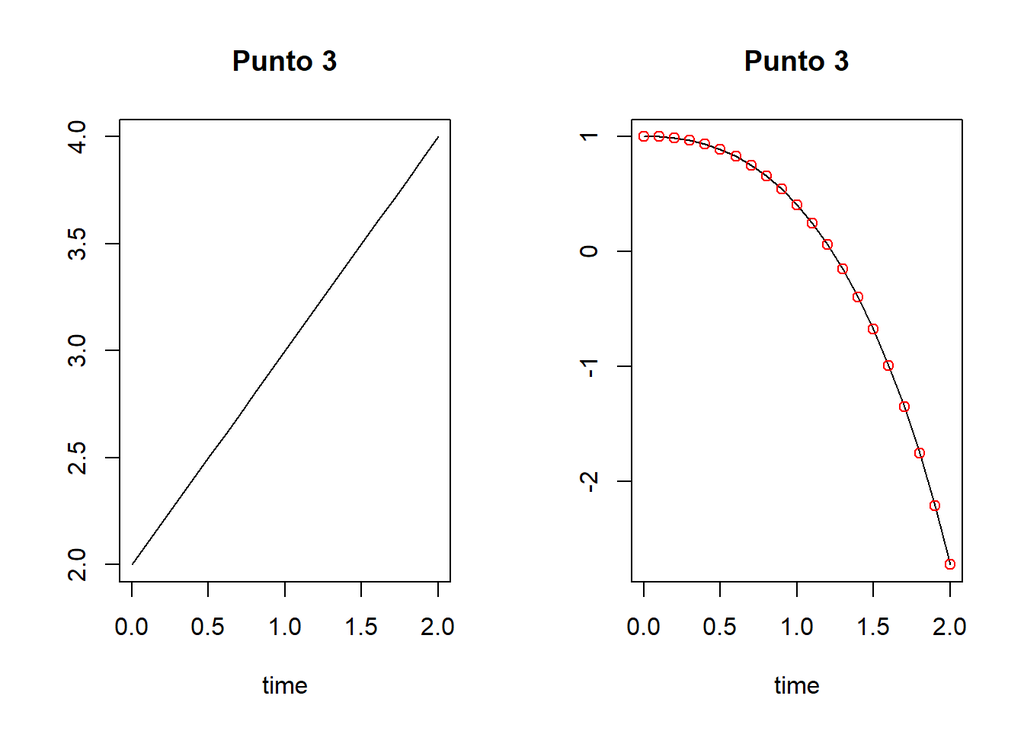

```r
#Realizado por Brayan Jesus Gonzalez Aguilera
#Solucion Punto 3
fp = function(t,y, parms){
  s = y - t - 1
  return(list(s))
}

h <- 0.1
tis= seq(0,20*h,h)

require(deSolve)
sol = ode(c(2,1), tis, fp, parms=NULL, method = "euler")
plot(sol,main="Punto 3")
par(new=T)
points(tis,sol[,3],col="red")
```

**Punto 5**  
Utilizando la ecuación del problema uno verifique la sensibilidad y la estabilidad del método.

```r
#Realizado por Brayan Jesus Gonzalez Aguilera
#Solucion punto 5
library(deSolve)
fp = function(t,y, parms){
  s = y -6*t
  return(list(s))
}

h <- 0.1
tis= seq(0,20*h,h)
require(deSolve)
sol = ode(c(2,-1), tis, fp, parms=NULL, method = "rk")
sol2 = ode(c(2,-1), tis, fp, parms=NULL, method = "euler")
exacta <- function(x){ return(exp(x/2)*(2*cos(sqrt(23)*x/2)-4/sqrt(23)*sin(sqrt(23)*x/2)))}

#Grafica Solucion exacta y Puntos de la solucion
plot(exacta,xlim=c(0,2),ylim=c(-5,5),col="red", xlab = "X", ylab= "Y", main="Punto 5")
par(new=T)
points(tis,sol[,3],xlim=c(0,1),ylim=c(-3,3),col="blue")
points(tis,sol2[,3],xlim=c(0,1),ylim=c(-3,3),col="black")


#options( digits = 5)
v <- c()
v2 <- c()
er <- c()

v3 <- c()
v4 <- c()
er2 <- c()

for( i in 1:20 ){
  v <- c(v,sol[i,3])
  v2 <- c(v2,exacta(i*h) )
  er <- c(er, abs( sol[i,3] - exacta(i*h) ) )
}

for( i in 1:20 ){
  v3 <- c(v3,sol2[i,3])
  v4 <- c(v4,exacta(i*h) )
  er2 <- c(er2, abs( sol2[i,3] - exacta(i*h) ) )
}


#Soluciones con PVI correcto
tabla = cbind( v[1:20] , cbind( v2[1:20], er[1:20]) )
colnames(tabla) = c("rk con h = 0.1", "Solucion Exacta ","Error")
tabla
```

```
##   rk con h = 0.1 Solucion Exacta    Error
## 2        -1.0000         1.834138  2.8341
## 2        -1.1362         1.535671  2.6719
## 2        -1.3498         1.109393  2.4592
## 2        -1.6490         0.568626  2.2176
## 2        -2.0428        -0.064716  1.9781
## 2        -2.5410        -0.760605  1.7804
## 2        -3.1548        -1.481923  1.6729
## 2        -3.8963        -2.186057  1.7102
## 2        -4.7788        -2.826988  1.9518
## 2        -5.8172        -3.357826  2.4594
## 2        -7.0280        -3.733662  3.2943
## 2        -8.4291        -3.914598  4.5145
## 2       -10.0408        -3.868773  6.1720
## 2       -11.8851        -3.575218  8.3098
## 2       -13.9864        -3.026310 10.9601
## 2       -16.3718        -2.229657 14.1421
## 2       -19.0712        -1.209225 17.8620
## 2       -22.1176        -0.005548 22.1120
## 2       -25.5475         1.325069 26.8725
## 2       -29.4012         2.712430 32.1136
```

```r
tabla2 = cbind( v3[1:20] , cbind( v4[1:20], er[1:20]) )
colnames(tabla2) = c("euler con h = 0.1", "Solucion Exacta ","Error")
tabla2
```

```
##   euler con h = 0.1 Solucion Exacta    Error
## 2           -1.0000         1.834138  2.8341
## 2           -1.1000         1.535671  2.6719
## 2           -1.2700         1.109393  2.4592
## 2           -1.5170         0.568626  2.2176
## 2           -1.8487        -0.064716  1.9781
## 2           -2.2736        -0.760605  1.7804
## 2           -2.8009        -1.481923  1.6729
## 2           -3.4410        -2.186057  1.7102
## 2           -4.2051        -2.826988  1.9518
## 2           -5.1056        -3.357826  2.4594
## 2           -6.1562        -3.733662  3.2943
## 2           -7.3718        -3.914598  4.5145
## 2           -8.7690        -3.868773  6.1720
## 2          -10.3659        -3.575218  8.3098
## 2          -12.1825        -3.026310 10.9601
## 2          -14.2407        -2.229657 14.1421
## 2          -16.5648        -1.209225 17.8620
## 2          -19.1813        -0.005548 22.1120
## 2          -22.1194         1.325069 26.8725
## 2          -25.4114         2.712430 32.1136
```

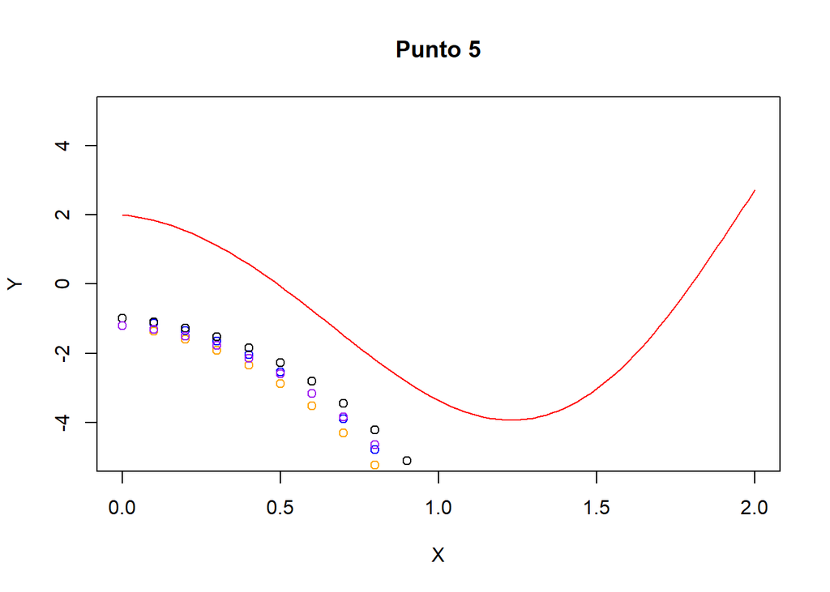

```r
#Soluciones con PVI incorrecto
sol3 = ode(c(2.3,-1.2), tis, fp, parms=NULL, method = "rk")
sol4 = ode(c(2.3,-1.2), tis, fp, parms=NULL, method = "euler")
points(tis,sol3[,3],xlim=c(0,1),ylim=c(-3,3),col="orange")
points(tis,sol4[,3],xlim=c(0,1),ylim=c(-3,3),col="purple")
```

```r
v5 <- c()
v6 <- c()
es3 <- c()
se <- c()

v7 <- c()
v8 <- c()
es4 <- c()
se2 <- c()

for( i in 1:20 ){
  v5 <- c(v5,sol[i,3])
  v6 <- c(v6,sol3[i,3])
  es3 <- c(es3, abs( sol[i,3]/sol3[i,3]) )
  se <- c(se,abs(sol[i,3]-sol3[i,3]))
}

for( i in 1:20 ){
  v7 <- c(v7,sol2[i,3])
  v8 <- c(v8,sol4[i,3])
  es4 <- c(es4, abs( sol2[i,3]/sol4[i,3]) )
  se2 <- c(se2,abs(sol2[i,3]-sol4[i,3]))
}

tabla3 = cbind( v5[1:20] , cbind( v6[1:20], es3[1:20]), se[1:20] )
colnames(tabla3) = c("PVI correcto rk ", "PVI incorrecto rk ","  Estabilidad rk","  Sensibilidad rk")
tabla3
```

```
##   PVI correcto rk  PVI incorrecto rk    Estabilidad rk   Sensibilidad rk
## 2          -1.0000            -1.2000          0.83333           0.20000
## 2          -1.1362            -1.3572          0.83714           0.22103
## 2          -1.3498            -1.5941          0.84676           0.24428
## 2          -1.6490            -1.9190          0.85932           0.26997
## 2          -2.0428            -2.3411          0.87256           0.29836
## 2          -2.5410            -2.8708          0.88514           0.32974
## 2          -3.1548            -3.5192          0.89645           0.36442
## 2          -3.8963            -4.2990          0.90632           0.40275
## 2          -4.7788            -5.2239          0.91479           0.44511
## 2          -5.8172            -6.3091          0.92203           0.49192
## 2          -7.0280            -7.5716          0.92820           0.54366
## 2          -8.4291            -9.0300          0.93346           0.60083
## 2         -10.0408           -10.7048          0.93797           0.66402
## 2         -11.8851           -12.6189          0.94184           0.73386
## 2         -13.9864           -14.7974          0.94519           0.81104
## 2         -16.3718           -17.2681          0.94809           0.89634
## 2         -19.0712           -20.0618          0.95062           0.99061
## 2         -22.1176           -23.2124          0.95284           1.09479
## 2         -25.5475           -26.7574          0.95478           1.20993
## 2         -29.4012           -30.7384          0.95650           1.33718
```